# Introduction to Bayesian Statistics

## Who was Bayes?

*An essay towards solving a problem on the doctrine of chances* (1763)

\[P(A|B) = \frac{P(B|A) P(A)}{P(B)}\]

[figure not shown]

## Bayes theorem lets us flip probabilities

We can use Bayes theorem to calculate the probability of one outcome conditional on another. For example, based on new information that we have obtained.

\[P(\text{rain}|\text{rain_forecast}) = \frac{P(\text{rain_forecast} | \text{rain}) P(\text{rain})}{P(\text{rain_forecast})}\]

## Bayes Theorem in practice

Beware random drugs tests! I like cycling, and lots of tests for EPO are conducted. Some urine [tests for micro-dosing](https://www.ncbi.nlm.nih.gov/pubmed/24190107) have a sensitivity (true positive) probability of 0.875 and a specificity (true negatives) of 0.98. Lets be generous and say a the proportion of cheaters is 0.005.

Say I get tested and return a positive… what is the probability that I, a randomly selected cyclist, cheated and doped with EPO?

\[P(User|+) = \frac{P(+|User) P(User)}{P(+)}\]

## Expanded EPO calculuations

\[P(\text{User}|+) = \frac{P(+|\text{User}) P(\text{User})}{P(+|\text{User})P(\text{User}) + P(+|\text{Non-user})P(\text{Non-user})}\]

- \(P(+|\text{User}) = 0.875\) These are the true positives
- \(P(-|\text{Non-user} = 0.98)\) These are the true Negatives
- \(P(\text{User}) = 0.005\) The proportion of users in the population

## EPO calculations in R

```r
sens <- 0.875 # Sensitivity of test (true positives)
spec <- 0.98 # Specificity of test (true negatives)
user <- 0.005 # proportion of cheats in the population

P_user_pos <- sens * user / ( (sens * user) + ( (1 - spec) * (1 - user) ) )

print(P_user_pos)
```

```
## [1] 0.1802266
```

And so, the probability that our randomly chosen cyclist who returned a positive is a cheater is only 0.18 and so it is far, far more likely that they did not cheat and take EPO.

## Questions

- what is the effect of increasing sensitivity and/or specificity?
- what is the effect of changing the proportion of cheats / users in the population?

## What is Bayesian statistics?

- Bayesian statistics is based on an interpretation of Bayes' theorem
- All quantities are divided up into *data* (i.e. things which have been observed) and *parameters* (i.e. things which haven't been observed)
- We use Bayes' interpretation of the theorem to get the *posterior probability distribution*, the probability of the unobserved given the observed
- Used now in almost all areas of statistical application (finance, medicine, environmetrics, gambling, etc, etc)

## What is Bayes' theorem?

Bayes' theorem can be written in words as:

\[\mbox{posterior is proportional to likelihood times prior}\] … or … \[\mbox{posterior} \propto \mbox{likelihood} \times \mbox{prior}\]

Each of the three terms *posterior*, *likelihood*, and *prior* are *probability distributions* (pdfs).

In a Bayesian model, every item of interest is either data (which we will write as \(x\)) or parameters (which we will write as \(\theta\)). Often the parameters are divided up into those of interest, and other *nuisance parameters*

## Bayes' theorem in more detail

Bayes' equation is usually written mathematically as: \[p(\theta|x) \propto p(x|\theta) \times p(\theta)\] or, more fully: \[p(\theta|x) = \frac{p(x|\theta) \times p(\theta)}{p(x)} = P(A|B) = \frac{P(B|A) P(A)}{P(B)}\]

- The *posterior* is the probability of the parameters given the data
- The *likelihood* is the probability of observing the data given the parameters (unknowns)
- The *prior* represents external knowledge about the parameters

## These parameters in more detail

- \(p(\theta|x)\) is the probability of a model parameter(s) given some data \(x\).
- \(p(x|\theta)\) is the probability of the data given a paremeter and is obtained from the likelihood function for a specified probability distribution.
- \(p(\theta)\) is the probability of our model parameter(s) across their full range, i.e. our prior.
- \(p(x)\) is the probability of our data, and is the mathematically difficult (impossible) one to calculate!

## A simple example

- An ecologist listens for the calls of the southern brown tree frog (*Litoria ewingi*)
- They want to know the mean length of the calls
- We will assume that the standard deviation of the calls is known to be 0.8 seconds
- They hear a call of length 3.1 seconds
- A study conducted the previous year estimated the mean to be 2.3 seconds with standard error 0.5 seconds

If we assume that the calls they hear are normally distributed then \(x\) follows a normal distribution with mean \(\theta\) and standard deviation 0.8s, written \(x|\theta \sim N(\theta,0.8^2)\). The prior distribution is \(\theta \sim N(2.3,0.5^2)\).

## Simple example (continued)

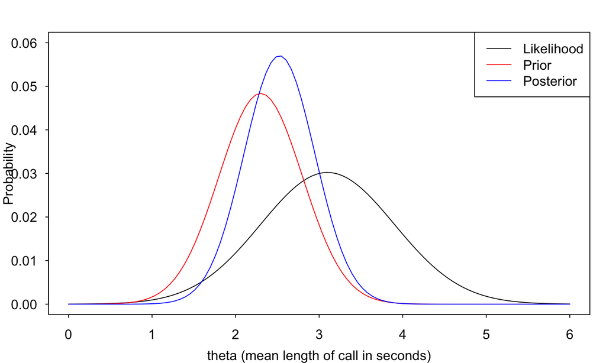

Note: posterior mean is 2.52 seconds and standard deviation is 0.42 seconds.

## Simple example (continued)

Code used to produce previous plot:

```r
# Create grid for theta
theta = seq(0,6,length=100)
# Evalutate prior, likelihood and posterior
prior = dnorm(theta,mean=2.3,sd=0.5)
likelihood = dnorm(3.1,mean=theta,sd=0.8)
posterior = prior*likelihood
# Produce plot
plot(theta,likelihood/sum(likelihood),type='l',
     ylab='Probability',ylim=c(0,0.06))
lines(theta,prior/sum(prior),col='red')
lines(theta,posterior/sum(posterior),col='blue')
legend('topright',legend=c('Likelihood','Prior',
                           'Posterior'),
       col=c('black','red','blue'),lty=1)
```

## Simple example in JAGS

In later modules we will start using JAGS to fit models like this. The code is much simpler than the previous R version:

```r
library(rjags)
modelstring ='
  model {
    # Likelihood
    x ~ dnorm(theta,0.8^-2)
    # Prior
    theta ~ dnorm(2.3,0.5^-2)
  }
'
# Set up data
data=list(x=3.1)
# Run jags
model=jags.model(textConnection(modelstring), data=data)
output=coda.samples(model=model,variable.names=c("theta"), n.iter=1000)
# Plot output
plot(density(output[[1]]))
```

Beware that JAGS uses *precision* (1/variance) rather than standard deviation in `dnorm`

## Plot from JAGS

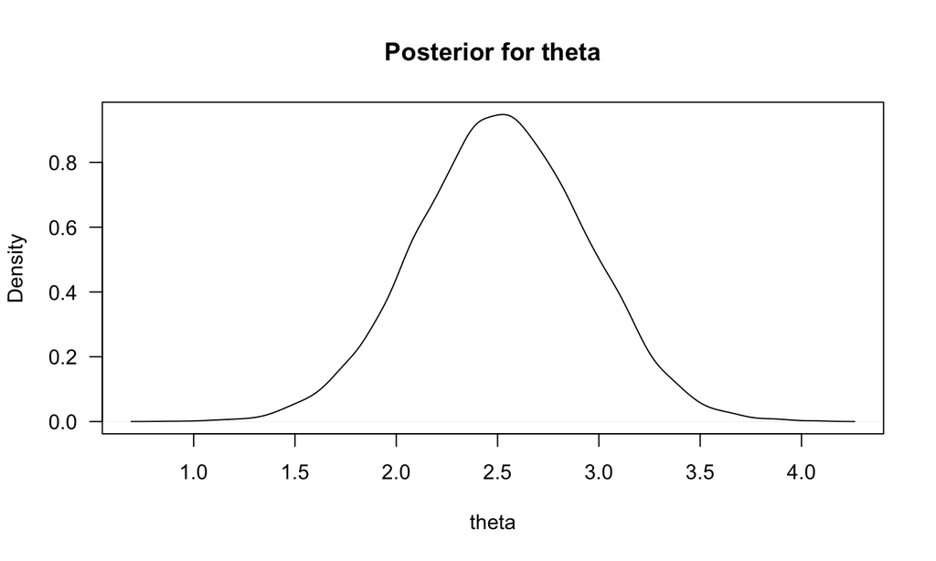

Posterior mean is 2.52 seconds and standard deviation is 0.42 seconds.

## What are the assumptions involved in this example?

- We've assumed that the normal distribution is appropriate for the likelihood and the prior
- We've only observed one data point. What if we observed many?
- We've assumed that the likelihood standard deviation is fixed at 0.8

## A more complicated JAGS version

```r
modelstring ='
  model {
    # Likelihood
    for(i in 1:n) { x[i] ~ dnorm(theta,sd^-2) }
    # Prior
    theta ~ dnorm(2.3,0.5^-2)
    sd ~ dunif(0,100)
  }
'
# Set up data
data=list(x=c(3.1,2.7,4.2,3.6),n=4)
# Run jags
model=jags.model(textConnection(modelstring), data=data)
output=coda.samples(model=model,variable.names=
                      c("theta","sd"), n.iter=1000)
```

Now have four data points, two parameters and a prior for each

## What if the observations aren't normal?

No problem! We just choose distributions which are appropriate for the type of data

```r
modelstring ='
  model {
    # Likelihood
    for(i in 1:n) {
      x[i] ~ dgamma(alpha, beta)
    }
    # Prior
    alpha ~ dunif(0, 100)
    beta ~ dunif(0, 100)
    # Mean
    mean <- alpha / beta
  }
'
data=list(x=c(3.1,2.7,4.2,3.6),n=4)
model=jags.model(textConnection(modelstring), data=data)
output=coda.samples(model=model,variable.names=c("mean"),n.iter=1000)
```

## How do I specify the prior distribution?

There are several choices when it comes to specifying prior distributions:

- *Informative*, when there is information from a previous study, or other good external source, e.g \(\theta \sim N(2.3,0.5^2)\)
- *Vague*, when there is only weak information, perhaps as to the likely range of the parameter e.g. \(\theta \sim U(0,100)\)
- *Flat*, when there is no information at all about a parameter (very rare). In JAGS, write `theta ~ dflat()`

Choosing the prior and choosing the likelihood are very similar problems

## Choosing likelihoods and priors

When creating Bayesian models it's helpful to know a lot of probability distributions. The ones we will use most are:

| Distribution | Range | Useful for: |
| --- | --- | --- |
| Normal, \(N(\mu,\sigma^2)\) | \((-\infty,\infty\)) | A good default choice |
| Uniform, \(U(a,b)\) | \((a,b)\) | Vague priors when we only know the range of the parameter |
| Binomial, \(Bin(k,\theta)\) | \([0,k]\) | Count or binary data restricted to have an upper value |
| Poisson, \(Po(\lambda)\) | \([0,\infty)\) | Count data with no upper limit |
| Gamma, \(Ga(\alpha,\beta)\) | \((0,\infty)\) | Continuous data with a lower bound of zero |
| Multivariate Normal, \(MVN(\mu,\Sigma)\) | \((-\infty,\infty\)) | Multivariate unbounded data with correlation between parameters/observations |
| Dirichlet, \(Dir(\alpha_1, \ldots, \alpha_k)\) | \((0, 1)\) | Multivariate proportions which must sum to 1 |

## Creating the posterior distribution

- In the very simple example, I was able to calculate the posterior distribution in just a couple of lines of `R` code
- When we have lots of parameters, and complicated prior distributions, we have to resort to *simulation*
- This means that we obtain *samples* from the posterior distribution rather than creating the probability distribution directly
- JAGS uses Markov chain Monte Carlo (MCMC) to create these samples. We will talk about this a bit more in later lectures/discussion

## Summarising the posterior distribution

- Because we obtain samples from the posterior distribution, we can create any quantity we like from them
- e.g. we can obtain the mean or standard deviation simply from combining the samples together
- We can create quantiles e.g. 50% for the median
- We can create a Bayesian *credible interval* (CI) by calculating lower and upper quantiles
- When the posterior distribution is messy (e.g. multi-modal) we can use a *highest posterior density* (HPD) region

## Example:

From the earlier simple example. First 5 posterior samples

```r
output[[1]][1:5]
```

```
## [1] 2.208815 2.350036 2.028822 2.589368 2.823275
```

The mean and standard deviation:

```r
c(mean(output[[1]]),sd(output[[1]]))
```

```
## [1] 2.5176936 0.4282672
```

A 95% credible interval

```r
quantile(output[[1]],probs=c(0.025,0.975))
```

```
##     2.5%    97.5%
## 1.681147 3.357246
```

## Why is this better?

The Bayesian approach has numerous advantages:

- It's easier to build complex models and to analyse the parameters you want directly
- We automatically obtain the best parameter estimates and their uncertainty from the posterior samples
- It allows us to get away from (terrible) null hypothesis testing and \(p\)-values

## Some further reading

- The Bayesian bible: Gelman, A., Carlin, J. B., Stern, H. S., Dunson, D. B., Vehtari, A., & Rubin, D. B. (2013). *Bayesian Data Analysis*, Third Edition. CRC Press.
- The MCMC bible: Brooks, S., Gelman, A., Jones, G., & Meng, X. (2011). *Handbook of Markov Chain Monte Carlo*. CRC Press.
- Something simpler: McCarthy, M. A. (2007). *Bayesian Methods for Ecology*. Cambridge University Press.

## Summary

- Bayesian statistical models involve a likelihood and a prior. These both need to be carefully chosen. From these we create a posterior distribution
- The likelihood represents the information about the data generating process, the prior represents information about the unknown parameters
- We usually create and analyse samples from the posterior probability distribution of the unknowns (the parameters) given the knowns (the data)
- From the posterior distribution we can create means, medians, standard deviations, credible intervals, etc